# Multiple Classification

In this exercise, will train a custome neural networks model that will accurately predict a sort of beer based on some evaluation criterias such as look, aroma, palate or flavor. We will be woking on the dataset: https://drive.google.com/file/d/1vYyJL_IB6KjKCxuk9kg4vIMPGTtoX8Ek/view

The steps are:

1. Setup Repository
2. Load and Explore data
3. Prepare Data
4. Train Model
5. Evaluation
6. Push Changes

```python
import pandas as pd
import numpy as np
import joblib
```

## 1. Setup Repository

**[1.1]** Go to the folder I created previously `adv_dsi_ass_2`

```python
cd /Users/frodo/Downloads/36114/project/adv_dsi_2023/adv_dsi_ass_2/ass_2
```

```
/Users/frodo/Downloads/36114/project/adv_dsi_2023/adv_dsi_ass_2/ass_2
```

**[1.2]** Copy the cookiecutter data science template

```python
cookiecutter -c v1 https://github.com/drivendata/cookiecutter-data-science
```

**[1.3]** Create a file called `Dockerfile` and add the following content:

```python
touch Dockerfile
```

```python
FROM jupyter/scipy-notebook:python-3.8.13
RUN pip install torch torchvision torchtext --extra-index-url https://download.pytorch.org/whl/cpu
ENV PYTHONPATH "${PYTHONPATH}:/home/jovyan/work"
WORKDIR /home/jovyan/work
```

**[1.4]** Build the image from this Dockerfile

```python
docker build -t pytorch-notebook:latest .
```

**[1.5]** Run the built Docker image

```python
docker run  -dit --rm --name adv_dsi_2023 -p 8888:8888 -e JUPYTER_ENABLE_LAB=yes -v ~/Projects/adv_dsi_2023/adv_dsi_ass_2:/home/jovyan/work -v ~/Projects/adv_dsi_2023/src:/home/jovyan/work/src pytorch-notebook:latest
```

**[1.6]** Display last 50 lines of logs

```python
docker logs --tail 50 adv_dsi_ass_2
```

**[1.7]** Initialise the repo

```python
git init
```

**[1.8]** In the local repo `adv_dsi_ass_2`,

```python
# Solution
git remote add origin git@github.com:frodorocky/adv_dsi_ass_2.git
```

**[1.9]** Add changes to git staging area and commit them

```python
# Solution
git add .
git commit -m "init"
```

**[1.10]** Push master branch to origin

```python
git push --set-upstream origin master
```

**[1.11]** Create a new git branch called `pytorch_reg`

```python
git checkout -b pytorch_reg
```

## 2. Load and explore data

We will do data cleaning and data exploration simultaneously because data exploration often goes hand in hand with data cleaning processes in our experiment

**[2.1]** Load the data in a dataframe called `df`

```python
df = pd.read_csv('data/raw/beer_reviews.csv')
```

**[2.2]** Display the first 5 rows of df

```python
df.head()
```

|  | brewery_id | brewery_name | review_time | review_overall | review_aroma | review_appearance | review_profilename | beer_style | review_palate | review_taste | beer_name | beer_abv | beer_beerid |
| --- | --- | --- | --- | --- | --- | --- | --- | --- | --- | --- | --- | --- | --- |
| 0 | 10325 | Vecchio Birraio | 1234817823 | 1.5 | 2.0 | 2.5 | stcules | Hefeweizen | 1.5 | 1.5 | Sausa Weizen | 5.0 | 47986 |
| 1 | 10325 | Vecchio Birraio | 1235915097 | 3.0 | 2.5 | 3.0 | stcules | English Strong Ale | 3.0 | 3.0 | Red Moon | 6.2 | 48213 |
| 2 | 10325 | Vecchio Birraio | 1235916604 | 3.0 | 2.5 | 3.0 | stcules | Foreign / Export Stout | 3.0 | 3.0 | Black Horse Black Beer | 6.5 | 48215 |
| 3 | 10325 | Vecchio Birraio | 1234725145 | 3.0 | 3.0 | 3.5 | stcules | German Pilsener | 2.5 | 3.0 | Sausa Pils | 5.0 | 47969 |
| 4 | 1075 | Caldera Brewing Company | 1293735206 | 4.0 | 4.5 | 4.0 | johnmichaelsen | American Double / Imperial IPA | 4.0 | 4.5 | Cauldron DIPA | 7.7 | 64883 |

**[2.3]** Display the shape of train data

```python
df.shape
```

```
(1586614, 13)
```

**[2.4]** Display the summary (info) of df

```python
df.info()
```

```
<class 'pandas.core.frame.DataFrame'>
RangeIndex: 1586614 entries, 0 to 1586613
Data columns (total 13 columns):
 #   Column              Non-Null Count    Dtype
---  ------              --------------    -----
 0   brewery_id          1586614 non-null  int64
 1   brewery_name        1586599 non-null  object
 2   review_time         1586614 non-null  int64
 3   review_overall      1586614 non-null  float64
 4   review_aroma        1586614 non-null  float64
 5   review_appearance   1586614 non-null  float64
 6   review_profilename  1586266 non-null  object
 7   beer_style          1586614 non-null  object
 8   review_palate       1586614 non-null  float64
 9   review_taste        1586614 non-null  float64
 10  beer_name           1586614 non-null  object
 11  beer_abv            1518829 non-null  float64
 12  beer_beerid         1586614 non-null  int64
dtypes: float64(6), int64(3), object(4)
memory usage: 157.4+ MB
```

**[2.5]** Display the ratio of missing values

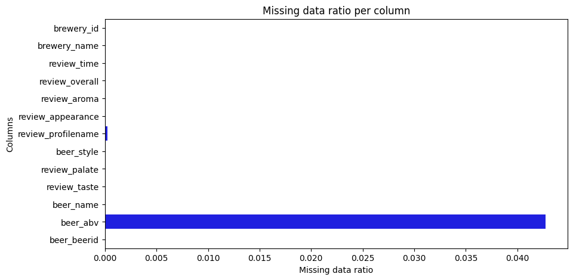

```python
import seaborn as sns
import matplotlib.pyplot as plt
import matplotlib
matplotlib.use('Qt5Agg')
%matplotlib inline

# Calculate the ratio of missing data for each column
missing_data_ratio = df.isnull().sum() / len(df)

# Convert the result into a DataFrame
missing_data_df = pd.DataFrame({'column_name': df.columns,
                                'missing_data_ratio': missing_data_ratio})

# Plot the graph
plt.figure(figsize=(10,5))
sns.barplot(x='missing_data_ratio', y='column_name', data=missing_data_df, color='blue')
plt.title('Missing data ratio per column')
plt.xlabel('Missing data ratio')
plt.ylabel('Columns')
plt.show()
```

**[2.6]** Display the descriptive statistics of df

```python
df.describe()
```

|  | brewery_id | review_time | review_overall | review_aroma | review_appearance | review_palate | review_taste | beer_abv | beer_beerid |
| --- | --- | --- | --- | --- | --- | --- | --- | --- | --- |
| count | 1.586614e+06 | 1.586614e+06 | 1.586614e+06 | 1.586614e+06 | 1.586614e+06 | 1.586614e+06 | 1.586614e+06 | 1.518829e+06 | 1.586614e+06 |
| mean | 3.130099e+03 | 1.224089e+09 | 3.815581e+00 | 3.735636e+00 | 3.841642e+00 | 3.743701e+00 | 3.792860e+00 | 7.042387e+00 | 2.171279e+04 |
| std | 5.578104e+03 | 7.654427e+07 | 7.206219e-01 | 6.976167e-01 | 6.160928e-01 | 6.822184e-01 | 7.319696e-01 | 2.322526e+00 | 2.181834e+04 |
| min | 1.000000e+00 | 8.406720e+08 | 0.000000e+00 | 1.000000e+00 | 0.000000e+00 | 1.000000e+00 | 1.000000e+00 | 1.000000e-02 | 3.000000e+00 |
| 25% | 1.430000e+02 | 1.173224e+09 | 3.500000e+00 | 3.500000e+00 | 3.500000e+00 | 3.500000e+00 | 3.500000e+00 | 5.200000e+00 | 1.717000e+03 |
| 50% | 4.290000e+02 | 1.239203e+09 | 4.000000e+00 | 4.000000e+00 | 4.000000e+00 | 4.000000e+00 | 4.000000e+00 | 6.500000e+00 | 1.390600e+04 |
| 75% | 2.372000e+03 | 1.288568e+09 | 4.500000e+00 | 4.000000e+00 | 4.000000e+00 | 4.000000e+00 | 4.500000e+00 | 8.500000e+00 | 3.944100e+04 |
| max | 2.800300e+04 | 1.326285e+09 | 5.000000e+00 | 5.000000e+00 | 5.000000e+00 | 5.000000e+00 | 5.000000e+00 | 5.770000e+01 | 7.731700e+04 |

**[2.7]** Distribution of Y

```python
df.beer_style.value_counts()
```

```
American IPA                        117586
American Double / Imperial IPA       85977
American Pale Ale (APA)              63469
Russian Imperial Stout               54129
American Double / Imperial Stout     50705
                                     ...
Gose                                   686
Faro                                   609
Roggenbier                             466
Kvass                                  297
Happoshu                               241
Name: beer_style, Length: 104, dtype: int64
```

**[2.8]** Distribution of X

```python
for column in df.columns:
    print(f"\nFeature: {column}")
    if df[column].dtype in ['int64', 'float64']:
        print(df[column].describe())
    else:
        print(df[column].value_counts())
```

```
Feature: brewery_id
count    1.586614e+06
mean     3.130099e+03
std      5.578104e+03
min      1.000000e+00
25%      1.430000e+02
50%      4.290000e+02
75%      2.372000e+03
max      2.800300e+04
Name: brewery_id, dtype: float64

Feature: brewery_name
Boston Beer Company (Samuel Adams)    39444
Dogfish Head Brewery                  33839
Stone Brewing Co.                     33066
Sierra Nevada Brewing Co.             28751
Bell's Brewery, Inc.                  25191
                                      ...
Brauerei Stolz GmbH & Co. KG              1
Hausbrauerei Düll                         1
Browar Grybów                             1
Staro&#269;eský Pivovárek Dobruka        1
Spire Brewery                             1
Name: brewery_name, Length: 5742, dtype: int64

Feature: review_time
count    1.586614e+06
mean     1.224089e+09
std      7.654427e+07
min      8.406720e+08
25%      1.173224e+09
50%      1.239203e+09
75%      1.288568e+09
max      1.326285e+09
Name: review_time, dtype: float64

Feature: review_overall
count    1.586614e+06
mean     3.815581e+00
std      7.206219e-01
```

[output cut: 99 more lines]

```
50%      6.500000e+00
75%      8.500000e+00
max      5.770000e+01
Name: beer_abv, dtype: float64

Feature: beer_beerid
count    1.586614e+06
mean     2.171279e+04
std      2.181834e+04
min      3.000000e+00
25%      1.717000e+03
50%      1.390600e+04
75%      3.944100e+04
max      7.731700e+04
Name: beer_beerid, dtype: float64
```

## 3. Prepare data

**[3.1]** Create a copy of `df` and save it into a variable called `df_cleaned`

```python
df_cleaned = df.copy()
```

**[3.2]** extract year and month from a timestamp

```python
# transform review_time into datetime
df_cleaned['review_time'] = pd.to_datetime(df_cleaned['review_time'], unit='s')

# create review_year and review_month
df_cleaned['review_year'] = df_cleaned['review_time'].dt.year
df_cleaned['review_month'] = df_cleaned['review_time'].dt.month
```

**[3.3]** Define id and drop irrelevant variables

```python
df_cleaned = df_cleaned.set_index(['beer_beerid','beer_name','review_time'])
```

```python
df_cleaned = df_cleaned.drop(axis=1, columns=['brewery_id'])
```

**[3.4]** Dealing missing value

```python
df_cleaned = df_cleaned.dropna()
```

**[3.5]** Extract the target variable into a variable called y

```python
y = df_cleaned.pop('beer_style')
```

**[3.6]** Mapping labels to numbers

```python
from sklearn.preprocessing import OneHotEncoder, LabelEncoder

label_encoder = LabelEncoder()
y_encoded = label_encoder.fit_transform(y)
```

**[3.7]** split dataset

```python
from sklearn.model_selection import train_test_split

# Convert DataFrames/Series to numpy arrays before splitting
X_trainval, X_test, y_trainval, y_test = train_test_split(df_cleaned, y_encoded, test_size=0.2, stratify=y,random_state=42)
X_train, X_val, y_train, y_val = train_test_split(X_trainval, y_trainval, test_size=0.25, stratify=y_trainval,random_state=42)
```

**[3.8]** Define customer dataset

```python
import torch
from torch.utils.data import Dataset, DataLoader
from sklearn.preprocessing import StandardScaler
from sklearn.pipeline import Pipeline
from sklearn.compose import ColumnTransformer
from sklearn.model_selection import train_test_split
```

```python
class MyDataset(Dataset):
    def __init__(self, data, target):
        self.data = data
        self.target = target

    def __getitem__(self, index):

        single_data = torch.from_numpy(self.data[index].todense()).float()
        single_target = torch.tensor(self.target[index]).long()
        return single_data, single_target

    def __len__(self):
        return self.data.shape[0]
```

**[3.9]** Define preprocessor to deal with numeric features and categorical features

```python
num_cols = df_cleaned.select_dtypes(include=['float64', 'float32', 'int64', 'int32']).columns
cat_cols = df_cleaned.select_dtypes(include=['object', 'category']).columns
```

```python
num_pipeline = Pipeline([
    ('scaler', StandardScaler())
])

cat_pipeline = Pipeline([
    ('onehot', OneHotEncoder(handle_unknown='ignore'))
])

preprocessor = ColumnTransformer([
    ('num', num_pipeline, num_cols),
    ('cat', cat_pipeline, cat_cols)
])
```

**[3.10]** Transform dataset

```python
X_train_preprocessed = preprocessor.fit_transform(X_train)
X_val_preprocessed = preprocessor.transform(X_val)
X_test_preprocessed = preprocessor.transform(X_test)
```

**[3.11]** # Ensure validation and test sets have the same number of columns as the training set

```python
# get OneHotEncoder from the fitted preprocessor
ohe = preprocessor.named_transformers_['cat'].named_steps['onehot']

# Get feature names from the OneHotEncoder
feature_names = ohe.get_feature_names_out(input_features=cat_cols)

# Get the number of columns in the training data
num_cols_train = len(feature_names)

if X_val_preprocessed.shape[1] < num_cols_train:
    # Add zero columns for any missing features in the validation data
    X_val_preprocessed = np.hstack([X_val_preprocessed, np.zeros((X_val_preprocessed.shape[0], num_cols_train - X_val_preprocessed.shape[1]))])

if X_test_preprocessed.shape[1] < num_cols_train:
    # Add zero columns for any missing features in the test data
    X_test_preprocessed = np.hstack([X_test_preprocessed, np.zeros((X_test_preprocessed.shape[0], num_cols_train - X_test_preprocessed.shape[1]))])
```

**[3.12]** Dataset Load

```python
train_dataset = MyDataset(X_train_preprocessed, y_train)
val_dataset = MyDataset(X_val_preprocessed, y_val)
test_dataset = MyDataset(X_test_preprocessed, y_test)
```

```python
train_loader = DataLoader(train_dataset, batch_size=32, shuffle=True)
val_loader = DataLoader(val_dataset, batch_size=32, shuffle=False)
test_loader = DataLoader(test_dataset, batch_size=32, shuffle=False)
```

**[3.13]** Save dataset to 'data/processed'

```python
np.save('data/processed/X_train_preprocessed.npy', X_train_preprocessed)
np.save('data/processed/X_val_preprocessed.npy', X_val_preprocessed)
np.save('data/processed/X_test_preprocessed.npy', X_test_preprocessed)

np.save('data/processed/y_train.npy', y_train)
np.save('data/processed/y_val.npy', y_val)
np.save('data/processed/y_test.npy', y_test)
```

## 4. Train model

**[4.1]** Initialize hyperparameter

```python
import torch
from torch import nn
from torch.optim import Adam

# set hyperparameter
input_size = X_train_preprocessed.shape[1]
hidden_size = 64
num_classes = len(np.unique(y_train))
num_epochs = 100
learning_rate = 0.01
```

**[4.2]** define model

```python
# define model
class MLP(nn.Module):
    def __init__(self, input_size, hidden_size, num_classes):
        super(MLP, self).__init__()
        self.fc1 = nn.Linear(input_size, hidden_size)
        self.relu = nn.ReLU()
        self.fc2 = nn.Linear(hidden_size, num_classes)

    def forward(self, x):
        out = self.fc1(x)
        out = self.relu(out)
        out = self.fc2(out)
        out = out.squeeze()
        return out
```

```python
# create model
device = torch.device("cuda" if torch.cuda.is_available() else "cpu")
print(device)

model = MLP(input_size, hidden_size, num_classes).to(device)
print(next(model.parameters()).device)
```

```
cpu
cpu
```

**[4.3]** define loss function and optimizer

```python
# define loss function and optimizer
criterion = nn.CrossEntropyLoss()
optimizer = torch.optim.SGD(model.parameters(), lr=learning_rate)
```

**[4.4]** plot model architecture

```python
from torchviz import make_dot

import os
os.environ["PATH"] += os.pathsep + '/opt/homebrew/bin'

input_data = torch.randn(1, input_size)
output = model(input_data)

dot = make_dot(output.mean(), params=dict(model.named_parameters()))
dot.format = 'png'
dot.render("network_structure")
```

```
'network_structure.png'
```

**[4.5]** train model

```python
best_loss = float('inf')

# Lists to save training and validation loss of each epoch
train_losses = []
val_losses = []

# train model
for epoch in range(num_epochs):
    train_loss = 0
    for i, (features, labels) in enumerate(train_loader):
        features = features.float()
        labels = labels.long()

        features = features.to(device)
        labels = labels.to(device)

        # Forward Propagation
        outputs = model(features)
        loss = criterion(outputs, labels)
        train_loss += loss.item()

        # Backpropagation
        optimizer.zero_grad()
        loss.backward()
        optimizer.step()

    train_loss /= len(train_loader)
    train_losses.append(train_loss)

    # validation
    model.eval()
    val_loss = 0
    with torch.no_grad():
        for i, (features, labels) in enumerate(val_loader):
            features = features.float()
            labels = labels.long()

            features = features.to(device)
            labels = labels.to(device)

            outputs = model(features)
            loss = criterion(outputs, labels)

            val_loss += loss.item()
        val_loss /= len(val_loader)
        val_losses.append(val_loss)

    # save best model
    if val_loss < best_loss:
        best_loss = val_loss
        torch.save(model.state_dict(), 'models/best_model.pth')

    print('Epoch [{}/{}], Train Loss: {:.4f}, Val Loss: {:.4f}'
          .format(epoch+1, num_epochs, train_loss, val_loss))
```

```
Epoch [1/100], Train Loss: 3.5277, Val Loss: 3.2835
Epoch [2/100], Train Loss: 3.1530, Val Loss: 3.0128
Epoch [3/100], Train Loss: 2.8690, Val Loss: 2.7321
Epoch [4/100], Train Loss: 2.6171, Val Loss: 2.5114
Epoch [5/100], Train Loss: 2.4208, Val Loss: 2.3406
Epoch [6/100], Train Loss: 2.2645, Val Loss: 2.2048
Epoch [7/100], Train Loss: 2.1410, Val Loss: 2.0996
Epoch [8/100], Train Loss: 2.0417, Val Loss: 2.0087
Epoch [9/100], Train Loss: 1.9597, Val Loss: 1.9402
Epoch [10/100], Train Loss: 1.8900, Val Loss: 1.8784
Epoch [11/100], Train Loss: 1.8295, Val Loss: 1.8252
Epoch [12/100], Train Loss: 1.7765, Val Loss: 1.7830
Epoch [13/100], Train Loss: 1.7293, Val Loss: 1.7425
Epoch [14/100], Train Loss: 1.6876, Val Loss: 1.7057
Epoch [15/100], Train Loss: 1.6495, Val Loss: 1.6708
Epoch [16/100], Train Loss: 1.6151, Val Loss: 1.6387
Epoch [17/100], Train Loss: 1.5834, Val Loss: 1.6152
Epoch [18/100], Train Loss: 1.5538, Val Loss: 1.5874
Epoch [19/100], Train Loss: 1.5266, Val Loss: 1.5772
Epoch [20/100], Train Loss: 1.5011, Val Loss: 1.5425
Epoch [21/100], Train Loss: 1.4772, Val Loss: 1.5272
Epoch [22/100], Train Loss: 1.4545, Val Loss: 1.5089
Epoch [23/100], Train Loss: 1.4333, Val Loss: 1.4892
Epoch [24/100], Train Loss: 1.4129, Val Loss: 1.4797
Epoch [25/100], Train Loss: 1.3938, Val Loss: 1.4571
Epoch [26/100], Train Loss: 1.3752, Val Loss: 1.4498
Epoch [27/100], Train Loss: 1.3581, Val Loss: 1.4277
Epoch [28/100], Train Loss: 1.3415, Val Loss: 1.4245
Epoch [29/100], Train Loss: 1.3257, Val Loss: 1.4087
Epoch [30/100], Train Loss: 1.3106, Val Loss: 1.3922
Epoch [31/100], Train Loss: 1.2959, Val Loss: 1.3830
Epoch [32/100], Train Loss: 1.2823, Val Loss: 1.3721
Epoch [33/100], Train Loss: 1.2689, Val Loss: 1.3652
Epoch [34/100], Train Loss: 1.2566, Val Loss: 1.3596
Epoch [35/100], Train Loss: 1.2443, Val Loss: 1.3443
Epoch [36/100], Train Loss: 1.2325, Val Loss: 1.3391
Epoch [37/100], Train Loss: 1.2213, Val Loss: 1.3367
Epoch [38/100], Train Loss: 1.2103, Val Loss: 1.3258
Epoch [39/100], Train Loss: 1.2000, Val Loss: 1.3188
Epoch [40/100], Train Loss: 1.1899, Val Loss: 1.3067
```

[output cut: 45 more lines]

```
Epoch [86/100], Train Loss: 0.9288, Val Loss: 1.1756
Epoch [87/100], Train Loss: 0.9256, Val Loss: 1.1615
Epoch [88/100], Train Loss: 0.9225, Val Loss: 1.1768
Epoch [89/100], Train Loss: 0.9191, Val Loss: 1.1624
Epoch [90/100], Train Loss: 0.9162, Val Loss: 1.1584
Epoch [91/100], Train Loss: 0.9126, Val Loss: 1.1730
Epoch [92/100], Train Loss: 0.9102, Val Loss: 1.1841
Epoch [93/100], Train Loss: 0.9067, Val Loss: 1.1659
Epoch [94/100], Train Loss: 0.9039, Val Loss: 1.1633
Epoch [95/100], Train Loss: 0.9007, Val Loss: 1.1573
Epoch [96/100], Train Loss: 0.8977, Val Loss: 1.1500
Epoch [97/100], Train Loss: 0.8955, Val Loss: 1.1598
Epoch [98/100], Train Loss: 0.8928, Val Loss: 1.1587
Epoch [99/100], Train Loss: 0.8901, Val Loss: 1.1589
Epoch [100/100], Train Loss: 0.8878, Val Loss: 1.1648
```

**[4.6]** plot loss graph

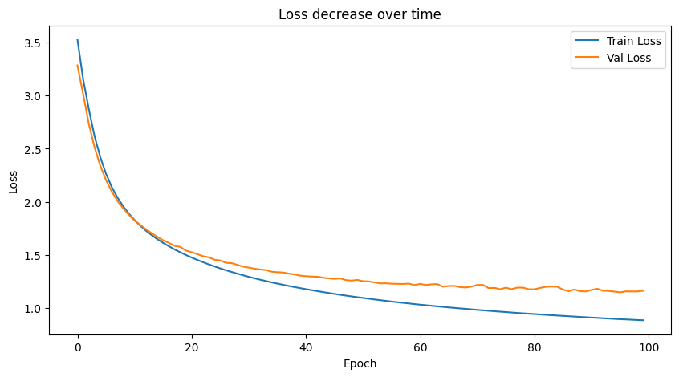

```python
# Plot the loss graph
plt.figure(figsize=(10,5))
plt.plot(train_losses, label='Train Loss')
plt.plot(val_losses, label='Val Loss')
plt.title("Loss decrease over time")
plt.xlabel("Epoch")
plt.ylabel("Loss")
plt.legend()
plt.show()
```

## 5. Evaluation on test data

**[5.1]** we applied the trained model on test data to obtain model performance

```python
from sklearn.metrics import classification_report
import numpy as np

# load best model
model.load_state_dict(torch.load('models/best_model.pth',map_location=device))

# predict and ground truth
y_pred = []
y_true = []

with torch.no_grad():
    for features, labels in test_loader:
        features = features.float()
        labels = labels.long()

        features = features.to(device)
        labels = labels.to(device)

        # prediction
        outputs = model(features)
        _, predicted = torch.max(outputs.data, 1)

        y_pred.extend(predicted.cpu().numpy().tolist())
        y_true.extend(labels.cpu().numpy().tolist())
```

**[5.2]** Evaluation

```python
# compute recision, recall, and f1 score
print(classification_report(y_true, y_pred, zero_division=1))
```

```
              precision    recall  f1-score   support

           0       0.64      0.50      0.56      1444
           1       0.75      0.86      0.80      5793
           2       0.54      0.55      0.54      8346
           3       0.58      0.59      0.59      1722
           4       0.73      0.75      0.74      5253
           5       0.47      0.48      0.48      2232
           6       0.42      0.30      0.35      2160
           7       0.63      0.55      0.59      4826
           8       0.22      0.11      0.15       239
           9       0.76      0.78      0.77     17021
          10       0.56      0.29      0.38      1079
          11       0.70      0.69      0.69     10027
          12       0.74      0.88      0.80     22629
```

[output cut: 95 more lines]

```python
class_names = label_encoder.classes_
```

```python
print(classification_report(y_true, y_pred, target_names=label_encoder.classes_))
```

```
                                     precision    recall  f1-score   support

                            Altbier       0.64      0.50      0.56      1444
             American Adjunct Lager       0.75      0.86      0.80      5793
           American Amber / Red Ale       0.54      0.55      0.54      8346
         American Amber / Red Lager       0.58      0.59      0.59      1722
                American Barleywine       0.73      0.75      0.74      5253
                 American Black Ale       0.47      0.48      0.48      2232
                American Blonde Ale       0.42      0.30      0.35      2160
                 American Brown Ale       0.63      0.55      0.59      4826
            American Dark Wheat Ale       0.22      0.11      0.15       239
     American Double / Imperial IPA       0.76      0.78      0.77     17021
 American Double / Imperial Pilsner       0.56      0.29      0.38      1079
   American Double / Imperial Stout       0.70      0.69      0.69     10027
                       American IPA       0.74      0.88      0.80     22629
               American Malt Liquor       0.79      0.73      0.76       766
            American Pale Ale (APA)       0.64      0.61      0.62     11614
                American Pale Lager       0.69      0.39      0.50      1673
            American Pale Wheat Ale       0.47      0.54      0.50      4578
                    American Porter       0.66      0.55      0.60      9329
                     American Stout       0.60      0.63      0.61      4521
                American Strong Ale       0.63      0.64      0.64      6270
                  American Wild Ale       0.64      0.58      0.61      3377
                      Baltic Porter       0.77      0.68      0.73      2284
                   Belgian Dark Ale       0.77      0.62      0.69      1256
                        Belgian IPA       0.61      0.51      0.55      2448
                   Belgian Pale Ale       0.65      0.57      0.60      3781
            Belgian Strong Dark Ale       0.61      0.72      0.66      7500
            Belgian Strong Pale Ale       0.58      0.64      0.61      6265
                 Berliner Weissbier       0.83      0.87      0.85       634
    Bière de Champagne / Bière Brut       0.64      0.66      0.65       208
                     Bière de Garde       0.71      0.58      0.64      1329
                        Black & Tan       0.55      0.37      0.44       439
                               Bock       0.45      0.39      0.42      2183
                            Braggot       0.95      0.31      0.46       203
     California Common / Steam Beer       0.71      0.45      0.55       764
                         Chile Beer       0.40      0.54      0.46       419
                          Cream Ale       0.37      0.59      0.45       944
                     Czech Pilsener       0.50      0.67      0.57      2406
                         Doppelbock       0.80      0.78      0.79      4203
```

[output cut: 55 more lines]

```
                        Schwarzbier       0.45      0.53      0.49      1882
             Scotch Ale / Wee Heavy       0.64      0.62      0.63      3334
                       Scottish Ale       0.66      0.54      0.60      1706
Scottish Gruit / Ancient Herbed Ale       0.85      0.77      0.81       546
                        Smoked Beer       0.34      0.23      0.27       566
                             Tripel       0.73      0.65      0.69      5994
                       Vienna Lager       0.50      0.31      0.39      1667
                         Weizenbock       0.80      0.65      0.72      1850
                          Wheatwine       0.68      0.40      0.50       720
                      Winter Warmer       0.54      0.68      0.60      3998
                            Witbier       0.56      0.52      0.54      5731

                           accuracy                           0.65    303696
                          macro avg       0.63      0.56      0.58    303696
                       weighted avg       0.65      0.65      0.64    303696
```

## 6. Push changes

**[6.1]** Add the changes to git staging area

```python
git add .
```

**[6.2]** Create the snapshot of the repository and add a description

```python
git commit -m "MLP"
```

**[6.3]** Push snapshot to Github

```python
git push --set-upstream origin main
```

**[6.4]** Check out to the branch

```python
git checkout main
```

**[6.5]** Pull the latest updates

```python
git pull
```

**[6.6]** Stop the Docker container

```python
docker stop adv_dsi_ass_2
```

## Reference

So, A. (2023). 36114_AdvDSI_Lab3_Exercise3_Solutions. https://drive.google.com/file/d/17UpMxkj4slAQ2BDyAeNEYzUfTA9Ww3x6/view